# Replication Script for IRT-M: Fast Item Response Theory With Interpretable Latent Dimensions

This script to produce a central runtime file for the simulations that analyze IRT-M vs Bayesian CFA and SEM (as implemented in blavaan) Last updated: 2025-07-23 06:57:46.32336

# Simulations:

```r
#source("bsem_N100_K10.R") ## ~ 200 entries
```

produces: irtm_bcfa_bsem_N100K10.rds ## model results small_sim_params.rds ## df of parameters irtm_bcfa_bsem_N100K10_time.rds ## runtime Produce results figures:

```
##
## > ## Results:
## > ## takes dataframe of results
## > ## produces graphs
## >
## > library(dplyr)
##
## > library(tidyr)
##
## > library(ggplot2)
##
## > source('irtm_bsem_results_to_df.R') ## script to format list of results as single df
##
## > source('na_indicies.R') # helper to find NA values in model comparisons
##
```

[output cut: 737 more lines]

```
##
## > ggsave(filename='simulations/results/figures/irt-bsem-bcfa.png',
## +        plot=p_results,
## +        dpi = 300,  width = 12, height=6)
```

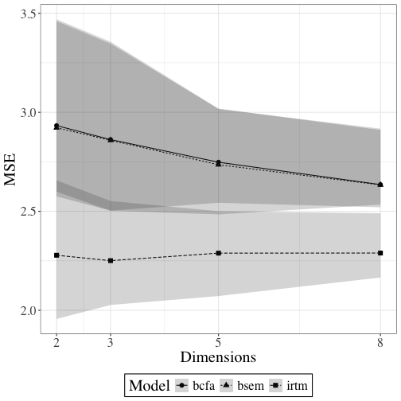

```
##
## > ## Time comparison
## >
## > p_time <- ggplot(time_results, aes(x= pass_d,
## +                                      y=avg,
## +                               .... [TRUNCATED]
##
## > p_time
```

```
##
## > ggsave(filename='simulations/results/figures/runtime_irt-bsem-bcfa.png',
## +        plot=p_time,
## +        dpi = 300,  width = 12, height=6)
```

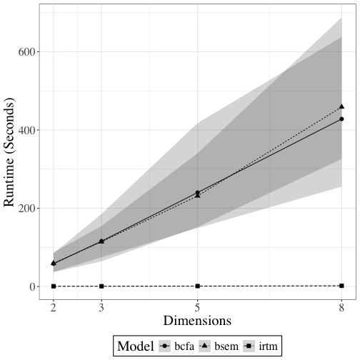

```
##
## > ## Percent failed models:
## > ## first count NA results by model and d specification
## >
## > ## Summarize the number of failed models
## > ## per dimension- .... [TRUNCATED]
##
## > ggmiss
```

```
##
## > ggsave(filename='simulations/results/figures/failed_models.png',
## +        plot=ggmiss,
## +        dpi = 300,
## +        width = 12,
## +        height=6)
```

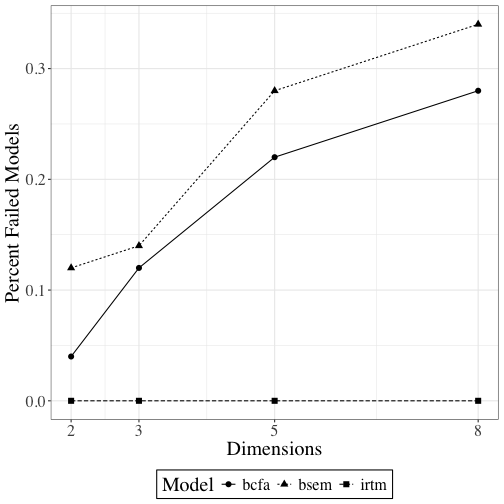

```
##
## > ## Boxplot for runtime, to get visibility into the
## > ## time spike at D=2
## >
## > ## For Fig 4: boxplot of run times
## >
## > runtime_all <- bsem_results_ .... [TRUNCATED]
## [1] 1
## [1] 2
## [1] 3
## [1] 4
## [1] 5
## [1] 6
## [1] 7
## [1] 8
```

[output cut: 206 more lines]

```
##
## > ggsave(filename='simulations/results/figures/runtime_boxplot.png',
## +        plot=grtbox,
## +        dpi = 300,
## +        width = 12,
## +        height= .... [TRUNCATED]
```

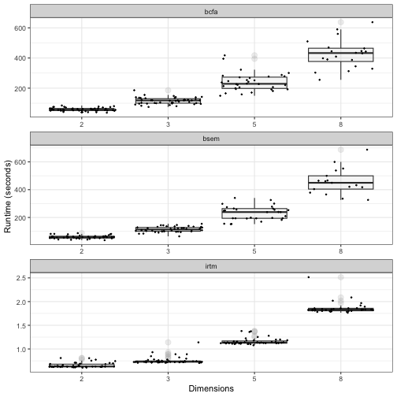

```r
source("bsem_results_plots.R", echo = TRUE)
```

Simulation for effect of Lambda Sparsity 120 entries, runs in about 8 hours on macbook pro source(“bsem_lambda_sparsity_sim.R”) produces: irtm_bcfa_bsem_lambda_sparsity_time.rds irtm_bcfa_bsem_lambda_sparsity.rds small_sim_params_sparsity.rds ## parameters

```
##
## > ## Results:
## > ## takes dataframe of results
## > ## produces graphs
## >
## > library(dplyr)
##
## > library(tidyr)
##
## > library(ggplot2)
##
## > source('irtm_bsem_results_to_df_lambds.R') ## script to format list of results as single df
##
## > source('na_indicies.R') # helper to find NA values in model comparisons
##
```

[output cut: 218 more lines]

```
##
## > sim_results$statistic <- "MSE" # for tracking
##
## > ## Data for Fig 2: Runtime by model
## > time_results <- bsem_results_to_df2(updated_time,
## +                                    small_sim,
## +            .... [TRUNCATED]
## [1] 1
## [1] 2
## [1] 3
## [1] 4
## [1] 5
## [1] 6
## [1] 7
## [1] 8
```

[output cut: 112 more lines]

```
##
## > time_results$statistic <- "runtime"
##
## > ## Data for Fig 3:  count NA by models:
## > na_count_by_group <- bsem_results_to_df2(all_results,
## +                                         small_sim, .... [TRUNCATED]
## [1] 1
## [1] 2
## [1] 3
## [1] 4
## [1] 5
## [1] 6
## [1] 7
## [1] 8
## [1] 9
```

[output cut: 111 more lines]

```
##
## > ##%%%%%%%%%%%%%%%%%%%%
## > ## Plots:
## >
## > p_results <- ggplot(sim_results, aes(x= pass_d,
## +                                      y=avg,
## +             .... [TRUNCATED]
##
## > p_results
```

```
##
## > ggsave(filename='simulations/results/figures/irt-bsem-bcfa_sparsity.png',
## +        plot=p_results,
## +        dpi = 300,  width = 12, height=6)
```

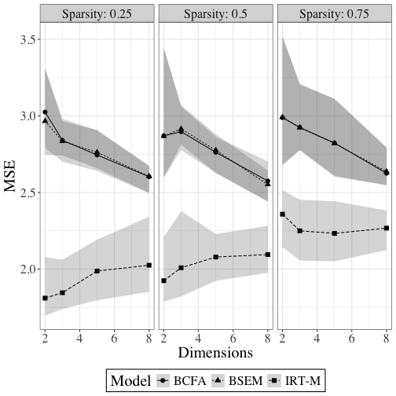

```
##
## > ## Time comparison
## >
## > ## the long bcfa and bsem times overwhelm variation in IRTM times:
## >
## > ## Might wnat to make this into a table:
## > ## number .... [TRUNCATED]
## # A tibble: 12 × 7
## # Groups:   pass_d [4]
##    pass_d Sparsity model   avg   min   max statistic
##     <dbl>    <dbl> <chr> <dbl> <dbl> <dbl> <chr>
##  1      2     0.25 IRT-M 0.652 0.611 0.737 runtime
##  2      2     0.5  IRT-M 0.694 0.620 1.07  runtime
##  3      2     0.75 IRT-M 0.648 0.601 0.844 runtime
##  4      3     0.25 IRT-M 0.779 0.706 0.936 runtime
##  5      3     0.5  IRT-M 0.736 0.704 0.784 runtime
##  6      3     0.75 IRT-M 0.765 0.712 1.04  runtime
##  7      5     0.25 IRT-M 1.16  1.12  1.25  runtime
##  8      5     0.5  IRT-M 1.13  1.10  1.16  runtime
##  9      5     0.75 IRT-M 1.12  1.10  1.15  runtime
## 10      8     0.25 IRT-M 1.85  1.79  2.09  runtime
## 11      8     0.5  IRT-M 1.88  1.78  2.14  runtime
## 12      8     0.75 IRT-M 1.80  1.75  1.89  runtime
##
## > p_time <- ggplot(time_results, aes(x= pass_d,
## +                                    y=avg,
## +                                    ymin=min,
## +         .... [TRUNCATED]
##
## > p_time
```

```
##
## > ggsave(filename='simulations/results/figures/runtime_irt-bsem-bcfa_lambda_sparse.png',
## +        plot=p_time,
## +        dpi = 300,  width = 12, heigh .... [TRUNCATED]
```

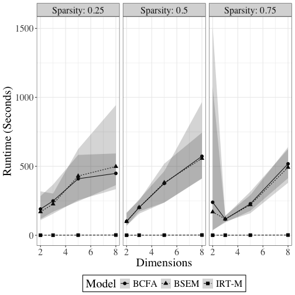

```
##
## > ## Percent failed models:
## > ## first count NA results by model and d specification
## >
## > ## Summarize the number of failed models
## > ## per dimension- .... [TRUNCATED]
##
## > ggmiss
```

```
##
## > ggsave(filename='simulations/results/figures/failed_models_lambda.png',
## +        plot=ggmiss,
## +        dpi = 300,
## +        width = 12,
## +        he .... [TRUNCATED]
```

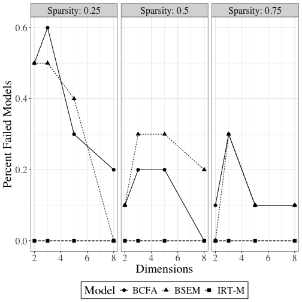

```r
#source("bsem_lambda_sparsity_sim.R")
## produces:
## irtm_bcfa_bsem_lambda_sparsity_time.rds
## irtm_bcfa_bsem_lambda_sparsity.rds
## small_sim_params_sparsity.rds ## parameters
##
## Produce results figures:
source("lamba_sparsity_plots.R", echo = TRUE)
```

```r
##%%%%%%%%%%%%%%%%%%%
## Benchmark time for a wider range of results:
##%%%%%%%%%%%%%%%%%%%%%%
```

simulation runs a wider N, K range for 10 passes each. Adjusted to standardize to seconds 6/25 480 entries, less cases where d > k took almost 20 days on macbook pro (commented out because of time) entire set, saves intermediate every 5:

```
##
## > library(dplyr)
##
## > library(tidyverse)
##
## > library(ggplot2)
##
## > source('results_to_df_range.R') ## script to format list of results as single df
##
## > source('na_indicies.R') # helper to find NA values in model comparisons
##
## > ## Load data:
## > ## Partial:
## > #load("irtm_bcfa_bsem_params_partial_.rds")
## > ## all_results:
```

[output cut: 1019 more lines]

```
## argument.
```

```
##
## > ## summarize time by model:
## > bsem_times = time_results[which(time_results$model=="bsem"),]
##
## > bcfa_times = time_results[which(time_results$model=="bcfa"),]
##
## > irtm_times = time_results[which(time_results$model=="irtm"),]
##
## > summary(bsem_times$min)
##    Min. 1st Qu.  Median    Mean 3rd Qu.    Max.
##   18.02  113.72  239.85  854.08  818.87 6845.47
##
## > summary(bcfa_times$min)
##    Min. 1st Qu.  Median    Mean 3rd Qu.    Max.
##   20.54  117.69  255.28  848.18  784.15 6939.95
##
## > summary(irtm_times$min)
##    Min. 1st Qu.  Median    Mean 3rd Qu.    Max.
##   0.212   1.380   3.110   6.153   7.146  33.533
##
## > summary(bsem_times$max)
##    Min. 1st Qu.  Median    Mean 3rd Qu.    Max.
##    33.9   250.6   664.1  3451.3  2174.8 57520.0
##
## > summary(bcfa_times$max)
##    Min. 1st Qu.  Median    Mean 3rd Qu.    Max.
##    29.9   258.2   707.5  2386.7  2574.4 18556.9
##
## > summary(irtm_times$max)
##    Min. 1st Qu.  Median    Mean 3rd Qu.    Max.
##  0.2275  1.4457  3.2600  6.4028  7.5202 34.4454
##
## > ## Plot of time variability:
## > ## to diagnose time stamp inconsistencies:
## >
## > # Create a parameter combo label
## > timing_df <- time_results %>%
## +    .... [TRUNCATED]
##
## > # Arrange levels in increasing N, then K, then D
## > ordered_levels <- timing_df %>%
## +   arrange(pass_N, pass_K, pass_d) %>%
## +   distinct(param_combo) .... [TRUNCATED]
##
## > # Apply the ordering to param_combo
## > timing_df <- timing_df %>%
## +   mutate(param_combo = factor(param_combo, levels = ordered_levels))
##
## > # Plot boxplots of average runtime per parameter combination, faceted by model
## >
## > timeplots = ggplot(timing_df, aes(x = param_combo, y = avg)) +
## + .... [TRUNCATED]
##
## > ##summary(time_results$max)
## >
## > timeplots
```

```
##
## > ggsave(filename='simulations/results/figures/timeplots_range_irt-bsem-bcfa.png',
## +        plot=timeplots,
## +        dpi = 300,  width = 12, height=6 .... [TRUNCATED]
```

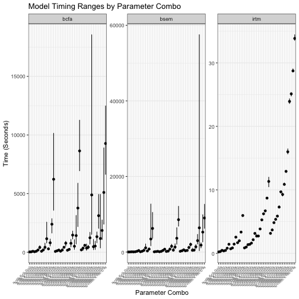

```
##
## > ## Data for Fig 3:  count NA by models:
## > na_count_by_group <- bsem_results_to_df(non_null_results,
## +                                         params .... [TRUNCATED]
## [1] 1
## [1] 2
## [1] 3
## [1] 4
## [1] 5
## [1] 6
## [1] 7
## [1] 8
## [1] 9
## [1] 10
## [1] 11
```

[output cut: 383 more lines]

```
## argument.
```

```
##
## > gg_sim_results <- bsem_results_to_df(non_null_results,
## +                                   params_df,
## +                                   mode = 1) .... [TRUNCATED]
## [1] 1
## [1] 2
## [1] 3
## [1] 4
## [1] 5
## [1] 6
## [1] 7
## [1] 8
## [1] 9
## [1] 10
## [1] 11
```

[output cut: 383 more lines]

```
## argument.
```

```
##
## > ## column names for labels:
## >
## > colnames(gg_sim_results)[which(colnames(gg_sim_results) == "pass_N")] <- "N"
##
## > colnames(gg_sim_results)[which(colnames(gg_sim_results) == "pass_K")] <- "K"
##
## > p_results <- ggplot(gg_sim_results, aes(x= pass_d,
## +                                      y=avg,
## +                                      ymin=min,
##  .... [TRUNCATED]
##
## > p_results
```

```
##
## > ggsave(filename='simulations/results/figures/MSE_range_irt-bsem-bcfa.png',
## +        plot=p_results,
## +        dpi = 300,  width = 12, height=6)
```

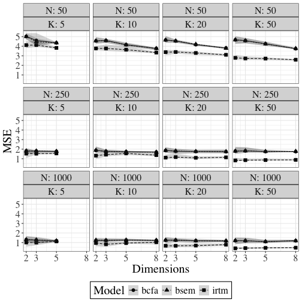

```
##
## > ## Time results
## >
## > colnames(time_results)[which(colnames(time_results) == "pass_N")] <- "N"
##
## > colnames(time_results)[which(colnames(time_results) == "pass_K")] <- "K"
##
## > t_results <- ggplot(time_results, aes(x= pass_d,
## +                                         y=avg,
## +                                         ymin=mi .... [TRUNCATED]
##
## > t_results
```

```
##
## > ggsave(filename='simulations/results/figures/time_range_irt-bsem-bcfa.png',
## +        plot=t_results,
## +        dpi = 300,  width = 12, height=6)
```

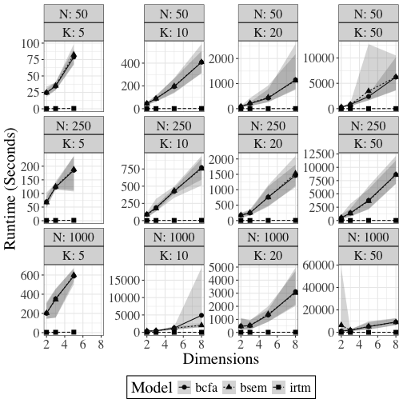

```
##
## > ### Failed runs:
## >
## > ## Plot model failures
## > colnames(na_count_by_group)[which(colnames(na_count_by_group) == "pass_N")] <- "N"
##
## > colnames(na_count_by_group)[which(colnames(na_count_by_group) == "pass_K")] <- "K"
##
## > ggmiss <- ggplot(na_count_by_group,
## +                  aes(x= pass_d,
## +                      y= pct_missing,
## +                      pch = as.factor .... [TRUNCATED]
##
## > ggmiss
```

```
##
## > ggsave(filename='simulations/results/figures/failed_models_range.png',
## +        plot=ggmiss,
## +        dpi = 300,
## +        width = 12,
## +        hei .... [TRUNCATED]
```

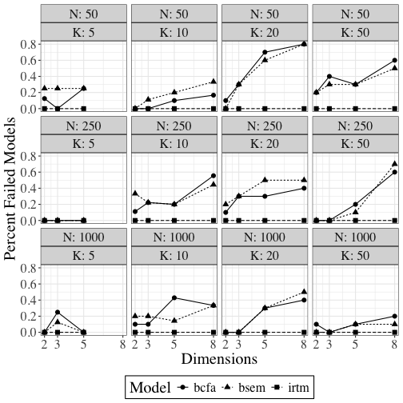

```
##
## > ## which am I waiting for:
## >
## > gg_remainder <- ggplot(na.omit(na_count_by_group),
## +                  aes(x= pass_d,
## +                      y= coun .... [TRUNCATED]
##
## > gg_remainder
```

```
##
## > ggsave(filename='simulations/results/figures/sim_progress.png',
## +        plot=gg_remainder,
## +        dpi = 300,
## +        width = 12,
## +        heig .... [TRUNCATED]
```

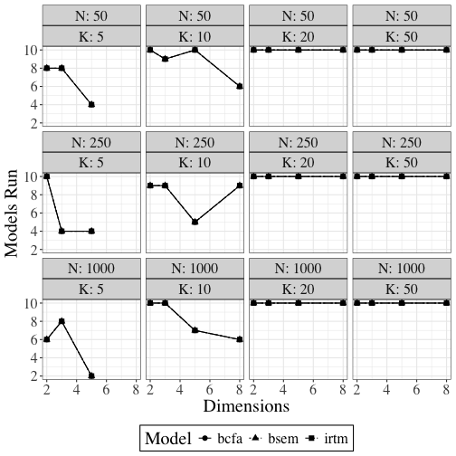

```r
#source("irtm_bsem_bcfa_sim_single_pass_for_time.R")

## #' plots
source("irtm_bsem_range_plots.R", echo = TRUE)
```